# Florida COVID-19 Trajectory

Roy Williams, Gabriel J. Odom, Zoran Bursac, and Mary Jo Trepka

04 January 2021

# Introduction

Public understanding of science is critical in times of crisis. The following analysis was conducted to examine the trajectory of COVID-19 in Florida. For phased reopening, the White House has set guidelines for local municipalities in their “Opening Up American Again” report. In the report, it is highly suggested that:

1. Local areas show a downward trajectory in the number of positive cases as a percent of total tests over a two-week period, and
2. Local hospitals have capacity to handle all patients without crisis care.

The analysis begins by looking at the number of new positive cases each day and the number of total tests performed each day. The figures are presented together because **as there is more testing, there are likely to be more positive test results**. Therefore, the proportion of positive cases is also calculated. Given either a flat or increasing number of tests performed, **the proportion of positive cases is the key metric to be used when looking at epidemic trajectory**. It is recommended that this proportion not exceed 5%.

**Note: 5-day moving averages are used to smooth data.**

**Note: On 8/31 there was a one-time historical data submission of a large number of cases from a large laboratory. The number of cases for 8/31 in the current report excludes this historical data submission.**

**Note: a data dump of previously reported results prevented the reporting system from normal processing of lab results on October 9th, causing an inaccurate representation of data for October 9th and October 10th.**

# COVID-19 Test Counts and Proportions

## Full Data

This is a table of the most recent data we have available. We include data sources at the end of the document.

| Date | Positive | Negative | PropPositive |
| --- | --- | --- | --- |
| 2020-06-07 | 1516 | 26419 | 5.40 |
| 2020-06-08 | 1812 | 30848 | 5.50 |
| 2020-06-09 | 1791 | 22038 | 7.50 |
| 2020-06-10 | 2298 | 29117 | 7.30 |
| 2020-06-11 | 2292 | 32271 | 6.60 |
| 2020-06-12 | 3479 | 36301 | 8.70 |
| 2020-06-13 | 2700 | 47699 | 5.40 |
| 2020-06-14 | 1765 | 31912 | 5.20 |
| 2020-06-15 | 2692 | 34570 | 7.20 |
| 2020-06-16 | 2410 | 21546 | 10.10 |
| 2020-06-17 | 2692 | 28047 | 8.80 |
| 2020-06-18 | 3301 | 30098 | 9.90 |
| 2020-06-19 | 4007 | 28701 | 12.30 |
| 2020-06-20 | 4636 | 34568 | 11.80 |
| 2020-06-21 | 2761 | 32917 | 7.70 |
| 2020-06-22 | 3829 | 32471 | 10.50 |
| 2020-06-23 | 5482 | 29171 | 15.80 |
| 2020-06-24 | 5019 | 50787 | 9.00 |
| 2020-06-25 | 8871 | 59318 | 13.00 |
| 2020-06-26 | 9571 | 65922 | 12.70 |
| 2020-06-27 | 8375 | 60687 | 12.10 |
| 2020-06-28 | 5380 | 34372 | 13.50 |
| 2020-06-29 | 6043 | 35396 | 14.60 |
| 2020-06-30 | 6569 | 36718 | 15.20 |
| 2020-07-01 | 9477 | 55469 | 14.60 |
| 2020-07-02 | 9406 | 53471 | 15.00 |
| 2020-07-03 | 11384 | 69066 | 14.20 |
| 2020-07-04 | 9920 | 56060 | 15.00 |
| 2020-07-05 | 6269 | 35582 | 15.00 |
| 2020-07-06 | 7301 | 37419 | 16.30 |

[output cut: 173 more lines]

The data above show for each day since June 8th: the number of positive COVID-19 tests, the number of negative COVID-19 tests, and the proportion of positive COVID-19 tests to total COVID-19 tests.

## Total COVID-19 Tests by Day

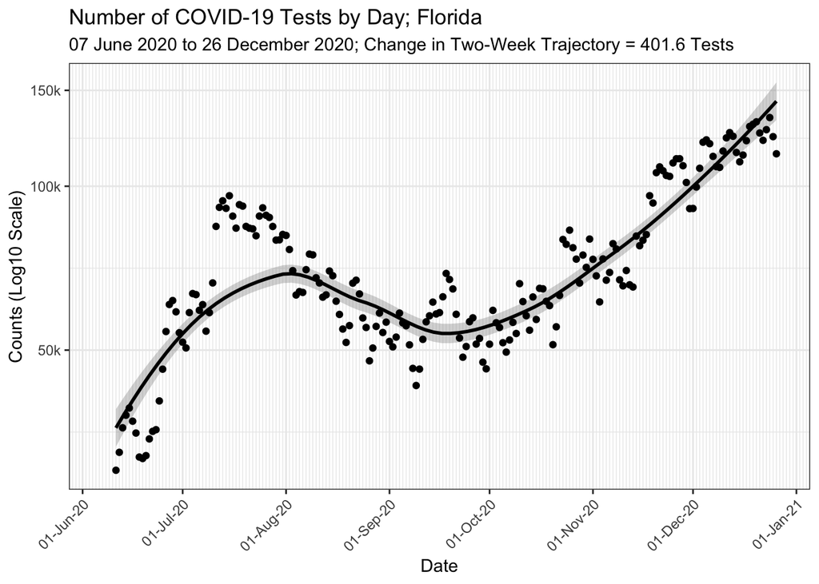

The average number of COVID-19 tests performed each day increased from under 35,000 in early June until plateauing around 100,000 in July. In August, this number dropped to approximately 50,000 test performed per day, before increasing again in the month of November to over 100,000 tests per day.

Over the past two weeks there was increase of 401.6 additional tests performed each day.

## Positive COVID-19 Tests by Day

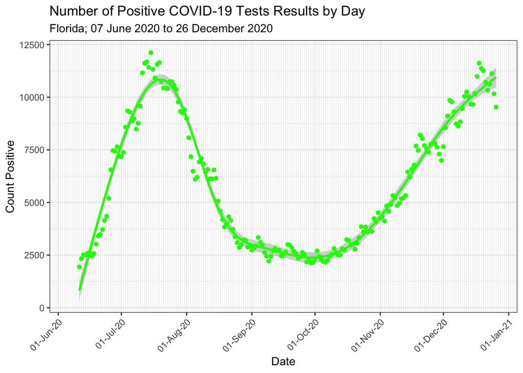

Over the past two weeks, there has been an average increase of 23 additional cases reported each day.

### Positive COVID-19 Tests within the Past Two Weeks

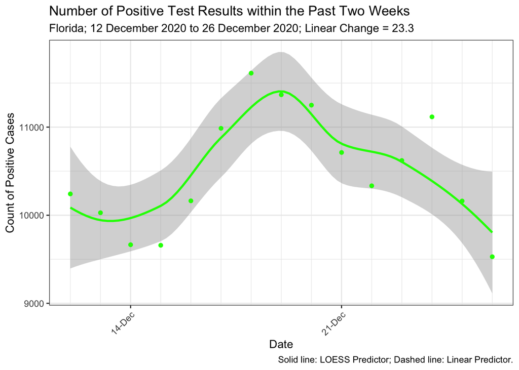

## Proportion of Positive Cases within Past Two Weeks

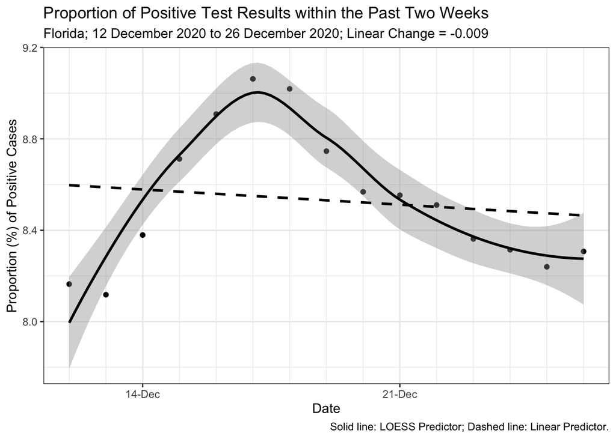

During the 14-day period from 12 December 2020 to 26 December 2020, there was a **slight decrease** in the proportion of positive COVID-19 cases reported in Florida. During this time, there was an average decrease of -0.009% per day for new positive cases.

## Proportion of Positive COVID-19 Tests by Day

These are the proportions of positive COVID-19 tests for the since the second week of June:

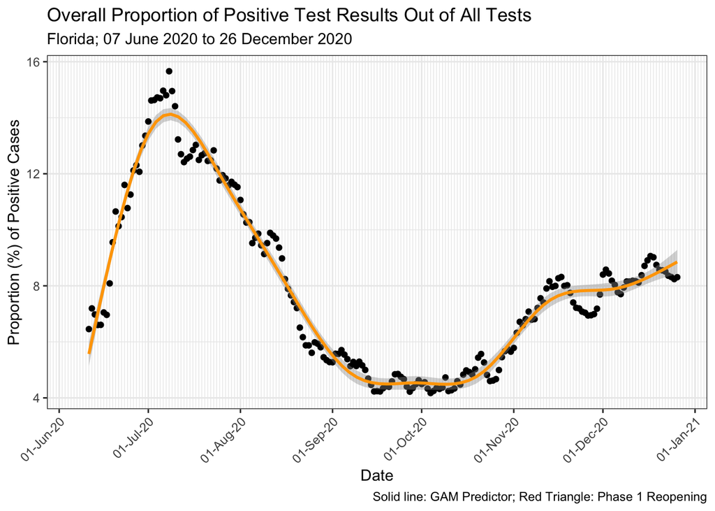

# COVID-19 Deaths by Day

| Date | Count |
| --- | --- |
| 2020-03-05 | 1 |
| 2020-03-07 | 1 |
| 2020-03-12 | 1 |
| 2020-03-13 | 3 |
| 2020-03-14 | 2 |
| 2020-03-15 | 4 |
| 2020-03-16 | 4 |
| 2020-03-17 | 4 |
| 2020-03-18 | 6 |
| 2020-03-19 | 3 |
| 2020-03-20 | 9 |
| 2020-03-21 | 14 |
| 2020-03-22 | 16 |
| 2020-03-23 | 15 |
| 2020-03-24 | 19 |
| 2020-03-25 | 32 |
| 2020-03-26 | 26 |
| 2020-03-27 | 55 |
| 2020-03-28 | 41 |
| 2020-03-29 | 55 |
| 2020-03-30 | 51 |
| 2020-03-31 | 35 |
| 2020-04-01 | 64 |
| 2020-04-02 | 61 |
| 2020-04-03 | 69 |
| 2020-04-04 | 48 |
| 2020-04-05 | 41 |
| 2020-04-06 | 51 |
| 2020-04-07 | 55 |
| 2020-04-08 | 66 |

[output cut: 231 more lines]

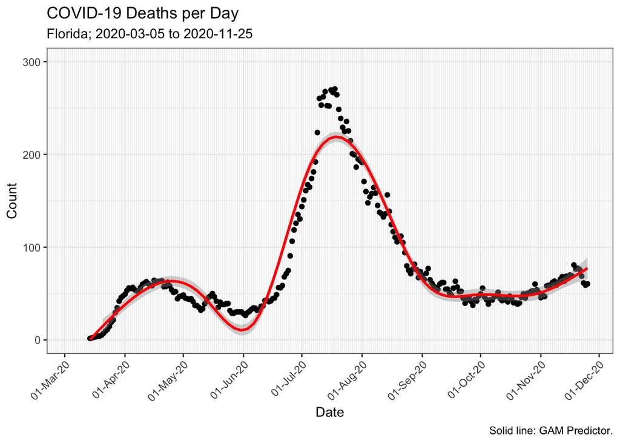

**Note: Due to delays in classifying the cause of death and thus of reporting deaths due to COVID-19, the most recent data will undercount the number of deaths. Specifically, 25% of new deaths added this week were from on or before November 25. This date indicates a point where 75% of our data is considered complete. For this reason, approximately the last 5.7 weeks were excluded from this analysis of deaths.**

# Conclusion

During the past two weeks, there has been a **increase** of 401.6 additional tests performed each day. There was an **increase** of 23 positive COVID-19 tests each day. There was a **slight decrease** in the proportion of positive COVID-19 tests of -0.009% each day. Finally, the number of deaths reported per day has begun to increase. There is now approximately a 5.7 week delay in the certification of deaths. Approximately 25% of new deaths added this week were from on or before November 25.

# Data Sources

Data sources are as follows:

- **COVID-19 Test Results**: The number of positive and negative COVID-19 test results come from the Florida Department of Health: https://urldefense.proofpoint.com/v2/url?u=https-3A__floridahealthcovid19.gov&d=DwIGaQ&c=lhMMI368wojMYNABHh1gQQ&r=ZzssdlRrRS7QXnhuTSa63A&m=QUKx3rCiMFnb5C5R588Kv_iCCiG7ii4YhxNZ61jfdrE&s=gADAIt0tyBXllksGsjeDHF-MEXNEXzo8hm1AX8DmV40&e= .
- **COVID-19 Hospital Census**: The hospitalization data is disseminated by Florida’s Agency for Health Care Administration: https://urldefense.proofpoint.com/v2/url?u=https-3A__ahca.myflorida.com&d=DwIGaQ&c=lhMMI368wojMYNABHh1gQQ&r=ZzssdlRrRS7QXnhuTSa63A&m=QUKx3rCiMFnb5C5R588Kv_iCCiG7ii4YhxNZ61jfdrE&s=6mSZjl-iVpEonWenx8CH16RY3Vlgg9DK7R6YTvD1O7Y&e= .
- **COVID-19 Death Linelist**: This list is created and disseminated by Florida’s Department of Health. Deaths are medical examiner confirmed. https://urldefense.proofpoint.com/v2/url?u=https-3A__floridahealthcovid19.gov&d=DwIGaQ&c=lhMMI368wojMYNABHh1gQQ&r=ZzssdlRrRS7QXnhuTSa63A&m=QUKx3rCiMFnb5C5R588Kv_iCCiG7ii4YhxNZ61jfdrE&s=gADAIt0tyBXllksGsjeDHF-MEXNEXzo8hm1AX8DmV40&e= .